# Assignment

Jungsok Lee

2019년 2월 28일

# 1. Code for reading in the dataset and/or processing the data

## Loading and preprocessing the data

firstly, I read data form activity.csv file which is placed at current working directory, then assigned the data to variable dat.

Then, I sum everyday total steps with tapply function, made dataframe having dates and total steps at that day as columns, and then removed rows that contains NA at steps column.

```r
dat <- read.csv("activity.csv")
View(dat)
class(dat$date)
```

```
## [1] "factor"
```

```r
dat$date <- as.Date(as.character(dat$date), "%Y-%m-%d")

steps_by_dates <- tapply(dat$steps, dat$date, sum)
steps_by_dates <- data.frame(names(steps_by_dates), steps_by_dates,row.names = 1:length(steps_by_dates))
names(steps_by_dates) <- c("dates", "steps")
steps_by_dates$dates <- as.Date(as.character(steps_by_dates$dates), "%Y-%m-%d")
steps_by_dates$steps <- as.numeric(as.character(steps_by_dates$steps))
steps_by_dates_T <- steps_by_dates[!is.na(steps_by_dates$steps),]
```

# 2. Histogram of the total number of steps taken each day

I made a histogram using dataframe I made right before.

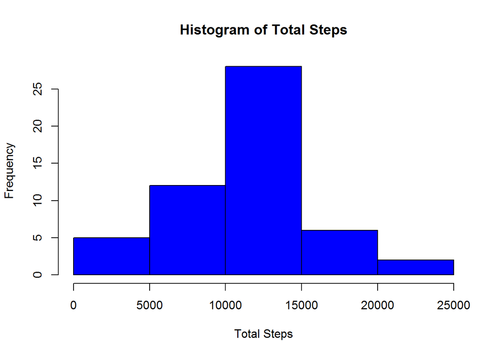

```r
hist(steps_by_dates_T$steps, xlab = "Total Steps", col = "blue", main = "Histogram of Total Steps")
```

# 3. Mean and median number of steps taken each day

I calcuated Mean and median Steps taken at each day.

```r
sprintf("Mean : %.2f", mean(steps_by_dates_T$steps))
```

```
## [1] "Mean : 10766.19"
```

```r
sprintf("Median : %d", median(steps_by_dates_T$steps))
```

```
## [1] "Median : 10765"
```